# Proyecto Índice de mora de la cartera de consumo

Análisis Exploratorio Incial

Autores/as

Esteban Daza Palomino

Juan David Garro Arboleda

Sara Jurado Giraldo

Fecha de publicación

28 de octubre de 2026

# 1 Construcción de la Serie

La serie es el índice de mora de la cartera de consumo de los establecimientos de crédito en Colombia: la proporción del saldo que tiene más de 30 días de atraso. Para cada mes se calcula como

$$\text{mora}_t = \frac{\text{saldo}_t - \text{saldo vigente}_t}{\text{saldo}_t} \times 100 .$$

La construimos con la base *Distribución de cartera por producto* de la Superintendencia Financiera. De esa base tomamos los ocho productos de consumo (códigos UNICAP 1 a 6, 29 y 30) y solo el renglón 5, que es el total de cada producto; los demás renglones lo desagregan y, si se suman, el saldo queda contado dos veces. El índice sale de sumar saldos y saldos vigentes de los ocho productos y de todas las entidades, así que cada producto pesa según su saldo.

La muestra va de enero de 2015 a julio de 2026 (139 meses). Según el mes reportaron entre 41 y 47 entidades.

| Base | Fuente | Para qué la usamos |
| --- | --- | --- |
| Distribución de cartera por producto (`rvii-eis8`) | datos.gov.co, se descarga por código | Construir el índice |
| Tasa de interés bancario corriente (`pare-7x5i`) | datos.gov.co, se descarga por código | Posible covariable |
| Calidad de cartera, histórico (`icv_historia.xlsx`) | Superintendencia Financiera | Validar el índice construido |
| Calidad de cartera incluido castigos (`icv_cas_historia.xlsx`) | Superintendencia Financiera | Revisar el efecto de diciembre |

# 2 Validación de la Serie Vs. IDC Oficial

Antes de usar la serie había que confirmar que el cálculo coincide con lo que publica la Superintendencia. El histórico oficial llega hasta diciembre de 2023, así que la comparación cubre 108 meses, de enero de 2015 a diciembre de 2023. La diferencia más grande entre las dos series es de 0,0123 puntos porcentuales; en la gráfica las líneas no se distinguen.

**Ver código**

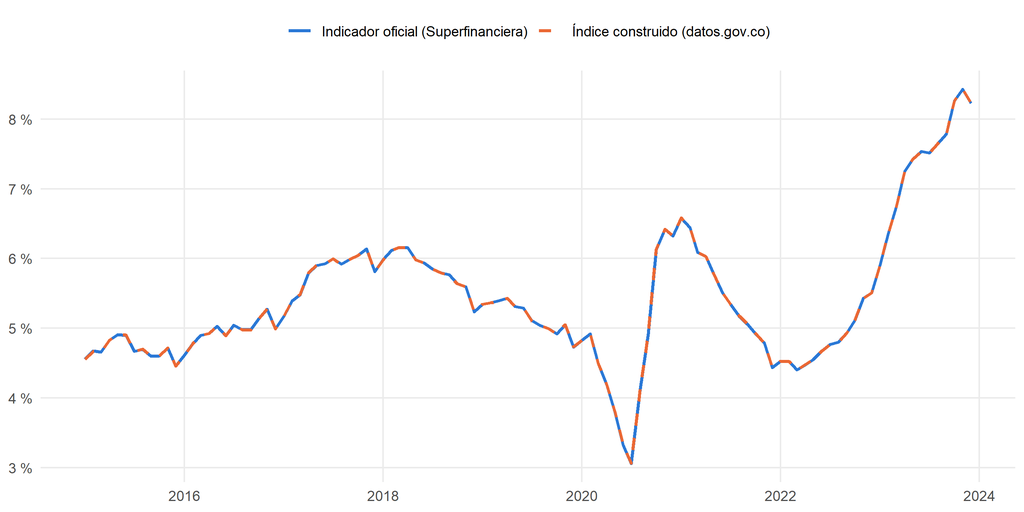

Figura 1: Índice construido frente al indicador oficial de calidad de cartera de consumo.

```r
validacion |>
  tidyr::pivot_longer(c(mora_construida, icv_oficial), names_to = "serie", values_to = "valor") |>
  mutate(serie = recode(serie,
                        mora_construida = "Índice construido (datos.gov.co)",
                        icv_oficial = "Indicador oficial (Superfinanciera)")) |>
  ggplot(aes(fecha, valor, colour = serie, linetype = serie)) +
  geom_line(linewidth = 0.9) +
  scale_colour_manual(values = c(azul, naranja)) +
  scale_linetype_manual(values = c("solid", "dashed")) +
  scale_y_continuous(labels = function(x) paste0(coma(x), " %")) +
  labs(x = NULL, y = NULL, colour = NULL, linetype = NULL) +
  theme_minimal(base_size = 11) +
  theme(legend.position = "top", panel.grid.minor = element_blank())
```

# 3 Serie Mora de Consumo Total

**Ver código**

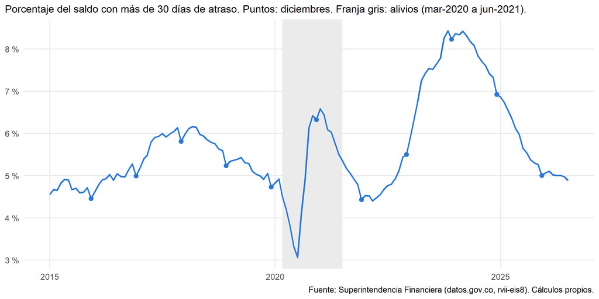

Figura 2: Índice de mora de la cartera de consumo.

```r
grafico_serie(total)
```

El índice se movió entre 3,06 % y 8,43 %. El mínimo fue en julio de 2020, en plena vigencia de los alivios de la pandemia: con las circulares de 2020 las entidades pudieron dar periodos de gracia y redefinir créditos, y esa cartera dejó de aparecer como vencida. Entre febrero de 2020 y el punto más bajo de ese año el índice cayó 1,86 puntos. Ese tramo no refleja un cambio real en el pago de los hogares, por eso en el modelo lo vamos a tratar con análisis de intervención y lo sacamos de los cálculos de estacionalidad.

Después de los alivios la mora subió hasta su máximo de noviembre de 2023, y desde ahí ha bajado. El último dato, de julio de 2026, es 4,89 %.

## 3.1 Período de Quiebre (Alivios por la Pandemia)

**Ver código**

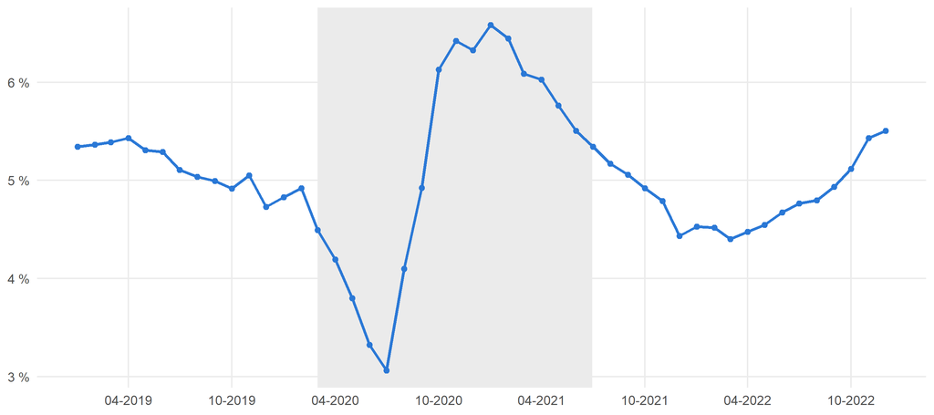

Figura 3: Índice de mora de consumo entre 2019 y 2022. Franja gris: alivios (marzo de 2020 a junio de 2021).

```r
valor_en <- function(f) total$mora_pct[total$fecha == as.Date(f)]
tramo_rebote <- filter(total, fecha >= as.Date("2020-08-01"), fecha <= as.Date("2021-06-01"))
rebote <- tramo_rebote[which.max(tramo_rebote$mora_pct), ]

total |>
  filter(fecha >= as.Date("2019-01-01"), fecha <= as.Date("2022-12-01")) |>
  ggplot(aes(fecha, mora_pct)) +
  annotate("rect", xmin = as.Date("2020-03-01"), xmax = as.Date("2021-06-30"),
           ymin = -Inf, ymax = Inf, fill = "grey92") +
  geom_line(colour = azul, linewidth = 0.9) +
  geom_point(colour = azul, size = 1.6) +
  scale_x_date(date_breaks = "6 months", date_labels = "%m-%Y") +
  scale_y_continuous(labels = function(x) paste0(coma(x), " %")) +
  labs(x = NULL, y = NULL) +
  theme_minimal(base_size = 11) +
  theme(panel.grid.minor = element_blank())
```

El efecto de los alivios no fue parejo durante los 16 meses. La mora bajó de 4,92 % en febrero de 2020 a 3,06 % en julio de 2020, mientras corrían los periodos de gracia. Cuando esos periodos se vencieron, la cartera atrasada volvió a aparecer y la mora subió hasta 6,58 % en enero de 2021, por encima del nivel de antes de la pandemia. De ahí fue bajando y cerró 2021 en 4,44 %.

Una sola variable que valga 1 en todo el periodo supone un efecto constante, y lo que se ve es una caída seguida de un rebote. Por eso en el análisis de intervención vamos a comparar varias formas: una indicadora para todo el periodo, un pulso al inicio de los alivios y otro en el rebote, y combinaciones de ellas.

# 4 Estacionalidad

Para ver el patrón de cada mes le quitamos a la serie su tendencia (media móvil 2x12) y promediamos lo que queda por mes, sin 2020 y 2021. Es el mismo cálculo de los índices estacionales de la descomposición clásica.

**Ver código**

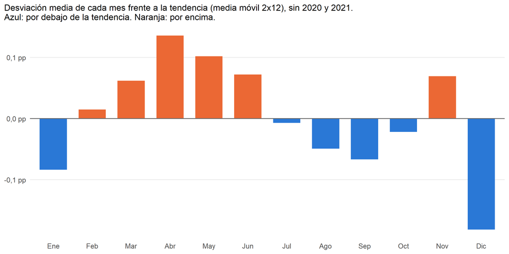

Figura 4: Perfil estacional del índice de mora.

```r
perfil_total <- perfil_mensual(total)
grafico_perfil(perfil_total)
```

El patrón se repite: la mora queda por debajo de su tendencia en diciembre (-0,18 pp) y enero (-0,08 pp), y por encima en abril (0,14 pp) y mayo (0,10 pp). Diciembre quedó por debajo de noviembre en 10/11 años entre 2015 y 2025. Con la descomposición clásica de 2015 a 2019 la fuerza estacional es 0,75, en una escala donde 0 es nada de estacionalidad y 1 es una serie dominada por ella.

Una explicación posible de la baja de diciembre son los castigos de fin de año: si las entidades sacan del balance la cartera vencida en diciembre, el índice baja aunque los hogares no paguen mejor. Para revisarlo comparamos con el indicador que suma los castigos:

**Ver código**

```r
perfil_sin <- validacion |> select(fecha, mora_pct = icv_oficial) |> perfil_mensual()
perfil_con <- validacion |> select(fecha, mora_pct = icv_con_castigos) |> perfil_mensual()

tibble::tibble(
  Mes = perfil_sin$mes,
  `Sin castigos (pp)` = num(perfil_sin$desviacion_media_pp),
  `Con castigos (pp)` = num(perfil_con$desviacion_media_pp)
) |>
  knitr::kable(align = "lrr",
               caption = "Desviación media frente a la tendencia, 2015-2023 sin 2020-2021.")
```

Desviación media frente a la tendencia, 2015-2023 sin 2020-2021.

| Mes | Sin castigos (pp) | Con castigos (pp) |
| --- | --- | --- |
| Ene | -0,15 | -0,15 |
| Feb | -0,02 | 0,12 |
| Mar | 0,03 | 0,24 |
| Abr | 0,14 | 0,28 |
| May | 0,11 | 0,21 |
| Jun | 0,07 | 0,08 |
| Jul | 0,02 | -0,03 |
| Ago | -0,04 | -0,10 |
| Sep | -0,07 | -0,12 |
| Oct | -0,07 | -0,13 |
| Nov | 0,03 | -0,14 |
| Dic | -0,23 | -0,46 |

Con castigos la baja de diciembre no desaparece (-0,46 pp frente a -0,23 pp), así que los castigos no la explican por sí solos. La caída viene de la cartera vencida, que en diciembre baja más que el saldo total.

La tabla completa por año y mes:

**Ver código**

```r
tabla_anio_mes(total) |>
  knitr::kable(format.args = list(decimal.mark = ","), col.names = c("Año", MESES))
```

| Año | Ene | Feb | Mar | Abr | May | Jun | Jul | Ago | Sep | Oct | Nov | Dic |
| --- | --- | --- | --- | --- | --- | --- | --- | --- | --- | --- | --- | --- |
| 2015 | 4,56 | 4,67 | 4,65 | 4,82 | 4,91 | 4,90 | 4,67 | 4,70 | 4,60 | 4,60 | 4,72 | 4,46 |
| 2016 | 4,62 | 4,78 | 4,90 | 4,93 | 5,03 | 4,89 | 5,05 | 4,98 | 4,98 | 5,14 | 5,28 | 4,99 |
| 2017 | 5,17 | 5,40 | 5,48 | 5,79 | 5,91 | 5,93 | 5,99 | 5,92 | 5,99 | 6,04 | 6,14 | 5,81 |
| 2018 | 5,98 | 6,12 | 6,16 | 6,15 | 5,98 | 5,94 | 5,85 | 5,79 | 5,76 | 5,64 | 5,59 | 5,24 |
| 2019 | 5,34 | 5,36 | 5,39 | 5,43 | 5,31 | 5,29 | 5,11 | 5,04 | 5,00 | 4,92 | 5,05 | 4,73 |
| 2020 | 4,83 | 4,92 | 4,49 | 4,20 | 3,80 | 3,32 | 3,06 | 4,10 | 4,92 | 6,13 | 6,42 | 6,33 |
| 2021 | 6,58 | 6,44 | 6,09 | 6,03 | 5,76 | 5,51 | 5,34 | 5,17 | 5,06 | 4,92 | 4,79 | 4,44 |
| 2022 | 4,53 | 4,52 | 4,40 | 4,48 | 4,55 | 4,67 | 4,76 | 4,80 | 4,93 | 5,12 | 5,43 | 5,51 |
| 2023 | 5,90 | 6,36 | 6,74 | 7,25 | 7,42 | 7,54 | 7,52 | 7,64 | 7,78 | 8,26 | 8,43 | 8,23 |
| 2024 | 8,36 | 8,34 | 8,42 | 8,31 | 8,17 | 8,08 | 7,84 | 7,71 | 7,61 | 7,42 | 7,33 | 6,92 |
| 2025 | 6,86 | 6,73 | 6,55 | 6,36 | 6,12 | 5,98 | 5,65 | 5,54 | 5,38 | 5,30 | 5,26 | 5,00 |
| 2026 | 5,07 | 5,10 | 5,02 | 5,01 | 5,00 | 4,98 | 4,89 |  |  |  |  |  |

# 5 Autocorrelación

**Ver código**

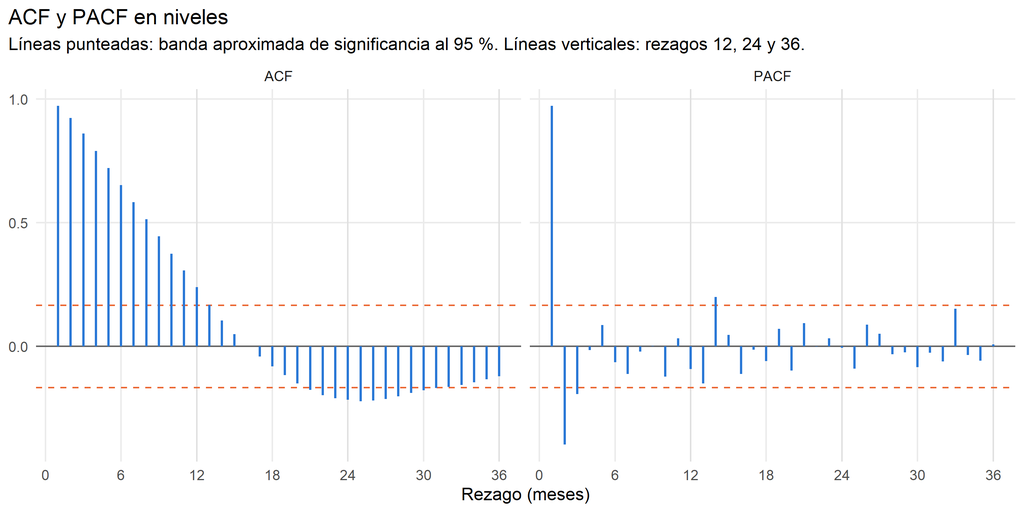

Figura 5: ACF y PACF del índice de mora en niveles.

```r
grafico_acf_pacf(total, diferencia = "ninguna")
```

En niveles la ACF baja muy despacio, lo esperable en una serie que no es estacionaria, así que hay que diferenciar.

Comparamos las tres opciones de diferenciación con la ACF en los rezagos 1 y 12:

**Ver código**

```r
acf_en <- function(dif, k) {
  calcular_acf_pacf(diferenciar(total$mora_pct, dif), 36) |>
    filter(funcion == "ACF", rezago == k) |>
    pull(valor)
}
banda <- 1.96 / sqrt(length(diferenciar(total$mora_pct, "ambas")))

tabla_dif <- tibble::tibble(
  dif = c("regular", "estacional", "ambas"),
  Diferencia = c("Regular (∇)", "Estacional (∇12)", "Regular y estacional (∇∇12)")
) |>
  mutate(r1  = purrr::map_dbl(dif, acf_en, k = 1),
         r12 = purrr::map_dbl(dif, acf_en, k = 12))

tabla_dif |>
  transmute(Diferencia, `ACF rezago 1` = num(r1), `ACF rezago 12` = num(r12)) |>
  knitr::kable(align = "lrr",
               caption = paste0("Banda aproximada de significancia: ±", num(banda), "."))
```

Banda aproximada de significancia: ±0,17.

| Diferencia | ACF rezago 1 | ACF rezago 12 |
| --- | --- | --- |
| Regular (∇) | 0,49 | 0,12 |
| Estacional (∇12) | 0,97 | -0,16 |
| Regular y estacional (∇∇12) | 0,66 | -0,45 |

**Ver código**

```r
acf_ambas <- tabla_dif$r12[tabla_dif$dif == "ambas"]
acf_est_1 <- tabla_dif$r1[tabla_dif$dif == "estacional"]
```

Con las dos diferencias aparece una autocorrelación de -0,45 en el rezago 12, cerca del −0,5 que deja diferenciar de más. Además, la diferencia estacional ya contiene a la regular, porque $1 - B^{12} = (1 - B)(1 + B + \dots + B^{11})$, de modo que aplicar también la regular puede sobrar. Por eso trabajamos solo con la diferencia estacional:

**Ver código**

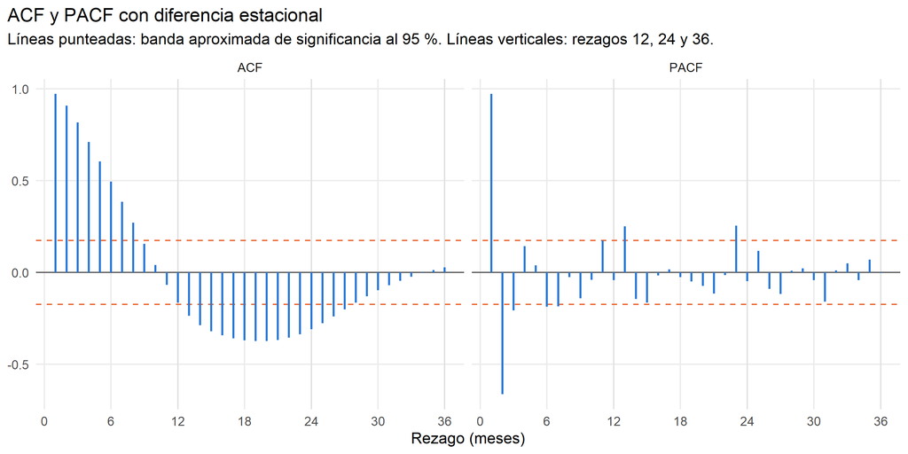

Figura 6: ACF y PACF del índice de mora con diferencia estacional.

```r
grafico_acf_pacf(total, diferencia = "estacional")
```

Con la diferencia estacional la ACF en el rezago 1 sigue alta (0,97) y baja despacio, así que la parte autorregresiva del modelo va a tener que recoger esa persistencia. Los órdenes del SARIMA(p,0,q)(P,1,Q)<sub>12</sub> los vamos a identificar con la muestra de entrenamiento y a respaldar la diferenciación con pruebas de raíz unitaria. Esta mirada todavía incluye el quiebre de 2020-2021.

# 6 Tasa de interés como covariable

**Ver código**

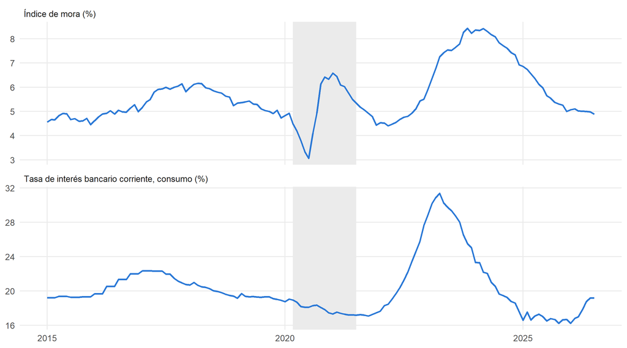

Figura 7: Índice de mora de consumo y tasa de interés bancario corriente de consumo.

```r
total |>
  select(fecha, `Índice de mora (%)` = mora_pct) |>
  left_join(select(tasa, fecha, `Tasa de interés bancario corriente, consumo (%)` = tibc_consumo),
            by = "fecha") |>
  tidyr::pivot_longer(-fecha, names_to = "variable", values_to = "valor") |>
  ggplot(aes(fecha, valor)) +
  annotate("rect", xmin = as.Date("2020-03-01"), xmax = as.Date("2021-06-30"),
           ymin = -Inf, ymax = Inf, fill = "grey92") +
  geom_line(colour = azul, linewidth = 0.8) +
  facet_wrap(~ variable, ncol = 1, scales = "free_y") +
  scale_y_continuous(labels = coma) +
  labs(x = NULL, y = NULL) +
  theme_minimal(base_size = 11) +
  theme(panel.grid.minor = element_blank(), strip.text = element_text(hjust = 0))
```

La tasa sube primero y la mora la sigue meses después: el ciclo de alzas de 2022 y 2023 coincide con el máximo de mora de 2023. Comparando los cambios mensuales de las dos series, sin 2020-2021, la correlación más alta con rezagos de 6 a 12 meses aparece a los 9 meses (0,60). Como la tasa entra con un rezago de al menos seis meses, para pronosticar hasta ese horizonte se usan valores ya observados y no hay que pronosticar también la tasa.

# 7 Finalización análisis exploratorio

Con esto termina la etapa exploratoria. La serie quedó construida y validada contra el indicador oficial, y con lo que encontramos ya están definidos los elementos del modelo: la estacionalidad se trata con la diferencia estacional, el periodo de los alivios con análisis de intervención y la tasa de interés entra como posible regresora con un rezago de al menos seis meses.

La siguiente etapa es la de identificación y estimación del modelo. Con la muestra de entrenamiento (enero de 2015 a diciembre de 2023) vamos a proponer los órdenes del SARIMA(p,0,q)(P,1,Q)<sub>12</sub>, comparar las formas de la intervención y revisar los residuos. Después el modelo elegido se evalúa con origen móvil frente al pronóstico naive estacional y un modelo de suavizamiento exponencial, con MASE y RMSE por horizonte, cobertura de los intervalos y la prueba de Diebold-Mariano.